# Introduction to R for Data Science

### Session 01: Introduction to R from RStudio IDE

11/07/2016, Belgrade, Serbia

Organized by: Data Science Serbia and [Startit](http://en.startit.rs)

## Lecturers

#### [Goran S. Milovanović](http://www.exactness.net), Phd

#### Data Science Mentor at [Springboard](https://www.springboard.com/workshops/data-science), [Data Science Serbia](http://www.datascience.rs)

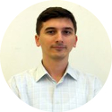

#### [ing Branko Kovač](https://rs.linkedin.com/in/kovacbranko)

#### Data Scientist @Tradecore, Data Science Mentor at [Springboard](https://www.springboard.com/workshops/data-science), [Data Science Serbia](http://www.datascience.rs)

### A. Installing R and RStudio

**Windows 7/8/10:**

1. Download the binary setup file for R from the following [link](https://cran.r-project.org/bin/windows/base/R-3.3.2-win.exe)
2. Open the downloaded file and install R by following installation instructions.
3. Download the binary setup file for RStudio from the following [link](https://download1.rstudio.org/RStudio-1.0.44.exe)
4. Open the downloaded file and install RStudio by following installation instructions.
5. Find RStudio shortcut in Start Menu and open RStudio by clicking on it.

**Apple OS X:**

1. Check OS X version: Choose “About This Mac” option from the Apple menu; the version number appears below the name.
2. Download the binary setup file for R from the following link:

###### **for OS X 10.9 and newer, [this link](https://cran.r-project.org/bin/macosx/R-3.3.2.pkg)**, or

###### **for OS X 10.6 – OS X 10.8, [this link](https://cran.r-project.org/bin/macosx/R-3.2.1-snowleopard.pkg)**

3. Open the downloaded file and install R by following installation instructions.
4. Download the binary setup file for RStudio from the following [link](https://download1.rstudio.org/RStudio-1.0.44.dmg)
5. Open the downloaded file and install RStudio by dragging the icon to Applications folder.
6. Find RStudio icon in Applications folder and open RStudio by clicking on it.

**Linux Ubuntu 16.04 Xenial Xerus**

1. To install R on Ubuntu 16.04 Xenial Xerus, follow the instructions [here](https://www.r-bloggers.com/how-to-install-r-on-linux-ubuntu-16-04-xenial-xerus/)
2. To install RStudio, visit [Download RStudio](https://www.rstudio.com/products/rstudio/download/) pages, pick the approprite (32/64 bit) version, download it, install it using any package manager; or,
3. using [gdebi](https://apps.ubuntu.com/cat/applications/precise/gdebi/), open Terminal and type (N.B. 64 bit version in example, please change accordingly):

###### **sudo apt-get install gdebi-core**

###### **wget https://download1.rstudio.org/rstudio-0.99.896-amd64.deb**

###### **sudo gdebi -n rstudio-0.99.896-amd64.deb**

###### **rm rstudio-0.99.896-amd64.deb**

4. Note: *The procedure follows the similar lines for previous versions of Ubuntu*

### B. R Playground

Ok. Now when we have our computing toy installed and ready, let’s see what it is about.

```r
# clear workspace
rm(list=ls())
# try this out:
ls()
```

```
## character(0)
```

Basically, R is an calculator:

```r
# R as a calculator
2+2
```

```
## [1] 4
```

```r
2/3-1+5
```

```
## [1] 4.666667
```

```r
a <- 1/3
b = 7
a + b
```

```
## [1] 7.333333
```

And more or less, that would be all. There’s numbers in R, there’s arithmetic in R, go do Data Science in R… Just kidding of course.

You need to know what’s your working directory:

```r
# what is my working directory?
getwd()
```

```
## [1] "/home/goran/Work/_DataScienceActual/DataScienceZajednica/IntroR_Autumn2016/Introduction to R for Data Science - Autumn 2016"
```

```r
# save R object as .rds file
saveRDS(a, "a.rds")
a <- readRDS("a.rds")
```

```r
# save several R objects as .RData file
save(list = c("a", "b"), file = "obj.RData")

# remove a, b
rm(a,b)
getwd()
```

```
## [1] "/home/goran/Work/_DataScienceActual/DataScienceZajednica/IntroR_Autumn2016/Introduction to R for Data Science - Autumn 2016"
```

```r
# load .RDatafile to R
load(file = "obj.RData")
```

```r
# list of loaded objects
ls()
```

```
## [1] "a" "b"
```

```r
# remove all objects
rm(list=ls())
```

### C. How to install CRAN packages in R and RStudio

After you have successfully installed both **R** and **RStudio**, you are ready to start programming in R. R has a plenty of built-in functions, but most of the time additional functions are needed. The true power of this programming language lies in the support from approximately 10,000 additional packages that can be installed to widen its functionality.

To install the packages that we are going to use during our course, please follow these steps:

1. Open RStudio from Start Menu (Windows users) or Applications folder (OS X users); Linux users: depends what desktop environment you use.
2. Assume that we want to install the package called: [dplyr](https://cran.r-project.org/web/packages/dplyr/index.html) (it is a well-known R package, indeed)
3. There are two ways to do it (actually, there are more than two ways, but let’s stick with the following two):

###### - **In the RStudio R console (the lower left quadrant of your RStudio workspace), type: install.packages(‘dplyr’)**

###### - **From the Tools menu in RStudio, select Instal Packages, then start typing the package name and select it from the list**

4. Most of the CRAN packages - those found in the standard, official R repository, called CRAN (Comprehensive R Archive Network) can be installed by following the standard procedure (described in Step 3). However, besides this basic package installation procedure, R packages from various sources can be installed in other ways as well. During the workshop we will demonstrate how to install R packages from the [GitHub](https://github.com/) repository (which is not R specific) using the devtools package from R, and how to install packages from the [Bioconductor](https://www.bioconductor.org/) repository.
5. *Note*: sometimes, most often in the R code comments, we use enclose the names of R packages in braces, like: {dplyr}, in order to visually mark the mention of an R package clearly.
6. *Note*: during the installation of some packages, you may notice how R starts installing additional packages - some packages that you have not selected for installation at all! The reason for this is the following: *some R packages rely on R functions developed in some other packages*. When an R package uses functions from another package, the later is called its **dependency**. R will automatically try to install all the dependencies of the package that you have selected for installation, so don’t be surprised if installing one package actually triggers and installation of a dozen of other packages at your system. It’s perfectly normal.

We will use many different R packages during the workshop. Here is a list of the packages that we will be needing; please take some time to practice package installation. To have the following packages pre-installed on the onset of our Workshop would really save us some time: [stringr](https://cran.r-project.org/web/packages/stringr/index.html), [stringi](https://cran.r-project.org/web/packages/stringi/index.html), [dplyr](https://cran.r-project.org/web/packages/dplyr/index.html), [tidyr](https://cran.r-project.org/web/packages/tidyr/index.html), [hflights](https://cran.rstudio.com/web/packages/hflights/index.html), [ggplot2](https://cran.r-project.org/web/packages/ggplot2/index.html), [corrplot](https://cran.r-project.org/web/packages/corrplot/index.html), [ppcor](https://cran.r-project.org/web/packages/ppcor/index.html), [Hmisc](https://cran.r-project.org/web/packages/Hmisc/index.html), [car](https://cran.r-project.org/web/packages/car/index.html), [QuantPsyc](https://cran.r-project.org/web/packages/QuantPsyc/index.html), [broom](https://cran.r-project.org/web/packages/broom/index.html), [lattice](https://cran.r-project.org/web/packages/lattice/index.html).

**REMINDER**: to install a package from the RStudio IDE, type in the console e.g.:

install.packages(“dplyr”)

```r
# installing packages:
# install.packages("dplyr") # replace "dplyr" with other package name
installed.packages() # list of installed packages
```

### D. The Shape of Things to Come

```r
# The shape of things to come:
numbers <- c(1,2,3,4,5)
words <- c("data", "science", "r")
boolean <- c(TRUE, FALSE)
data("mtcars")
head(mtcars,5)
```

```
##                    mpg cyl disp  hp drat    wt  qsec vs am gear carb
## Mazda RX4         21.0   6  160 110 3.90 2.620 16.46  0  1    4    4
## Mazda RX4 Wag     21.0   6  160 110 3.90 2.875 17.02  0  1    4    4
## Datsun 710        22.8   4  108  93 3.85 2.320 18.61  1  1    4    1
## Hornet 4 Drive    21.4   6  258 110 3.08 3.215 19.44  1  0    3    1
## Hornet Sportabout 18.7   8  360 175 3.15 3.440 17.02  0  0    3    2
```

```r
# define a function in R:

factorial <- function(x) {
  if (x == 0 | x == 1) {
    return(1)
  }
  else {
    return(x*factorial(x-1))
    }
}

# calls to factorial():
factorial(5)
```

```
## [1] 120
```

```r
factorial(10)
```

```
## [1] 3628800
```

```r
factorial(100)
```

```
## [1] 9.332622e+157
```

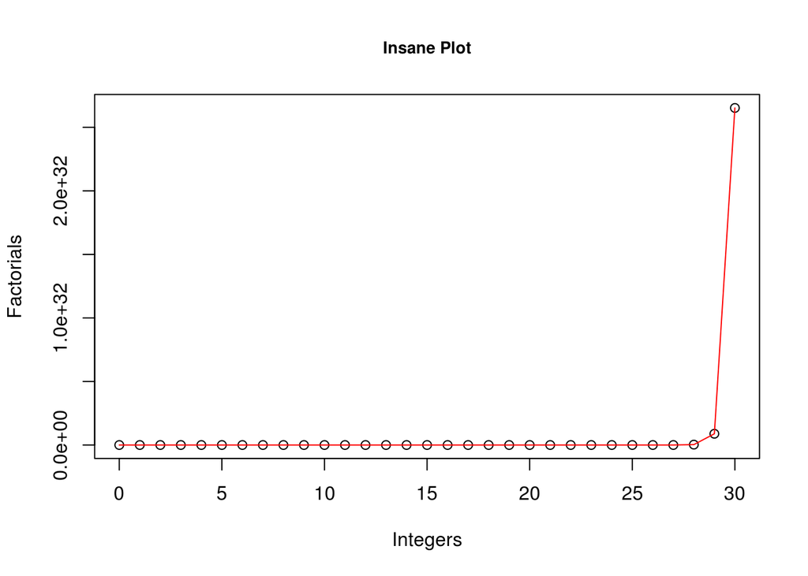

```r
# a vector of type numeric obtained from a sequence:
x <- seq(0,30,1)

# applying the non-vectorized factorial() function to a vector x:
xFactorials <- unlist(lapply(x, function(x) {factorial(x)}))

# a {base} R plot
plot(x,xFactorials,
     xlab = "Integers",
     ylab = "Factorials",
     main = "Insane Plot",
     cex.main = .85)
lines(x,xFactorials, col="red")
```

```r
# R is a vector programming language. All programming languages dream of becoming
# vector languages one day. For example, to do vector programming in Python, you first need
# a package called NumPy to turn it into MATLAB, then a package named Pandas to turn it into R.
# Just kidding :) - we love Python too and have the highest of respect only for the
# Python community in Data Science. But R is a "natural" vector programming language:

# create 100 random deviates from the Uniform on [0,1]
x <- runif(100,0,1)

# ask for *each element in x* whether it is >= .5 or not:
x>=.5
```

```
##   [1] FALSE FALSE FALSE FALSE FALSE FALSE FALSE  TRUE  TRUE FALSE FALSE
##  [12]  TRUE  TRUE FALSE FALSE FALSE  TRUE FALSE FALSE  TRUE FALSE FALSE
##  [23] FALSE FALSE FALSE FALSE FALSE FALSE FALSE  TRUE FALSE FALSE FALSE
##  [34]  TRUE FALSE  TRUE FALSE FALSE  TRUE FALSE  TRUE FALSE  TRUE  TRUE
##  [45] FALSE FALSE  TRUE FALSE FALSE  TRUE  TRUE  TRUE  TRUE FALSE FALSE
##  [56]  TRUE  TRUE  TRUE FALSE FALSE  TRUE  TRUE  TRUE  TRUE  TRUE FALSE
##  [67]  TRUE  TRUE FALSE FALSE  TRUE  TRUE  TRUE  TRUE  TRUE  TRUE FALSE
##  [78]  TRUE  TRUE FALSE FALSE  TRUE FALSE  TRUE FALSE FALSE  TRUE FALSE
##  [89] FALSE  TRUE FALSE  TRUE  TRUE FALSE  TRUE FALSE FALSE  TRUE  TRUE
## [100] FALSE
```

```r
# Where's the function? Isn't >= an operator?
# R is a functional programming language too. Thus:
logical1 <- '>='(x,.5)
logical2 <- x>=.5
which(logical1 != logical2) # none: integer(0)
```

```
## integer(0)
```

```r
# Back to vectorized functions in R; similarly, we have:
x <- seq(2,100,2)
x2 <- sqrt(x)
x2
```

```
##  [1]  1.414214  2.000000  2.449490  2.828427  3.162278  3.464102  3.741657
##  [8]  4.000000  4.242641  4.472136  4.690416  4.898979  5.099020  5.291503
## [15]  5.477226  5.656854  5.830952  6.000000  6.164414  6.324555  6.480741
## [22]  6.633250  6.782330  6.928203  7.071068  7.211103  7.348469  7.483315
## [29]  7.615773  7.745967  7.874008  8.000000  8.124038  8.246211  8.366600
## [36]  8.485281  8.602325  8.717798  8.831761  8.944272  9.055385  9.165151
## [43]  9.273618  9.380832  9.486833  9.591663  9.695360  9.797959  9.899495
## [50] 10.000000
```

Ok. Let strech its legs now:

```r
# PCA
library(psych)
library(FactoMineR)
library(ggplot2)
dataSet <- bfi[,1:25]
dim(dataSet)
```

```
## [1] 2800   25
```

```r
# replace NA w. respective column means
for(i in 1:ncol(dataSet)){
  dataSet[is.na(dataSet[,i]), i] <- mean(dataSet[,i], na.rm = TRUE)
}
colnames(dataSet)
```

```
##  [1] "A1" "A2" "A3" "A4" "A5" "C1" "C2" "C3" "C4" "C5" "E1" "E2" "E3" "E4"
## [15] "E5" "N1" "N2" "N3" "N4" "N5" "O1" "O2" "O3" "O4" "O5"
```

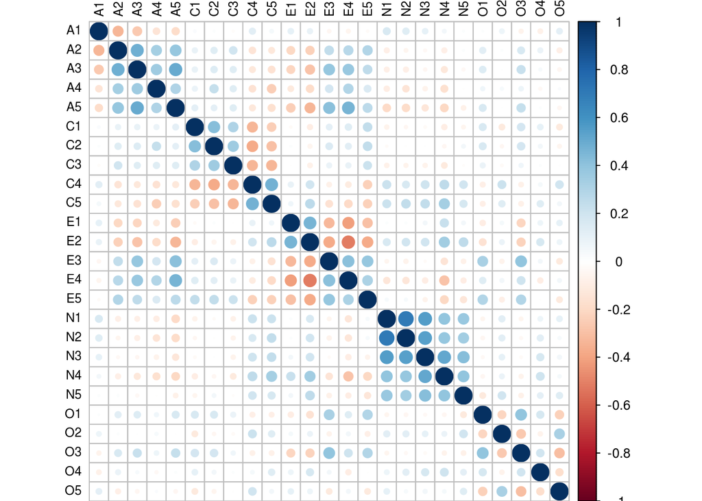

```r
# plot correlation matrix
library(corrplot)
corrplot(cor(dataSet),
         tl.col='black',
         tl.cex=.75)
```

```r
# perform PCA w. PCA() from {factoMineR}
pcaSolution <- PCA(dataSet,
                   ncp=5,
                   scale.unit=F,
                   graph=FALSE)
# Eigenvalues:
eigenvalues <- pcaSolution$eig$eigenvalue
names(eigenvalues) <- paste("Component: ", seq(1,length(eigenvalues)), sep = "")
eigenvalues
```

```
##  Component: 1  Component: 2  Component: 3  Component: 4  Component: 5
##    13.8478647     8.5489712     5.8666608     4.2193872     3.4703813
##  Component: 6  Component: 7  Component: 8  Component: 9 Component: 10
##     2.3300286     2.2166478     2.0364989     1.7182894     1.5736218
## Component: 11 Component: 12 Component: 13 Component: 14 Component: 15
##     1.4465899     1.2729182     1.1808628     1.1037853     1.0825310
## Component: 16 Component: 17 Component: 18 Component: 19 Component: 20
##     0.9752362     0.9209653     0.8152593     0.8024804     0.7630872
## Component: 21 Component: 22 Component: 23 Component: 24 Component: 25
##     0.7458680     0.7117674     0.6928534     0.6611319     0.6180367
```

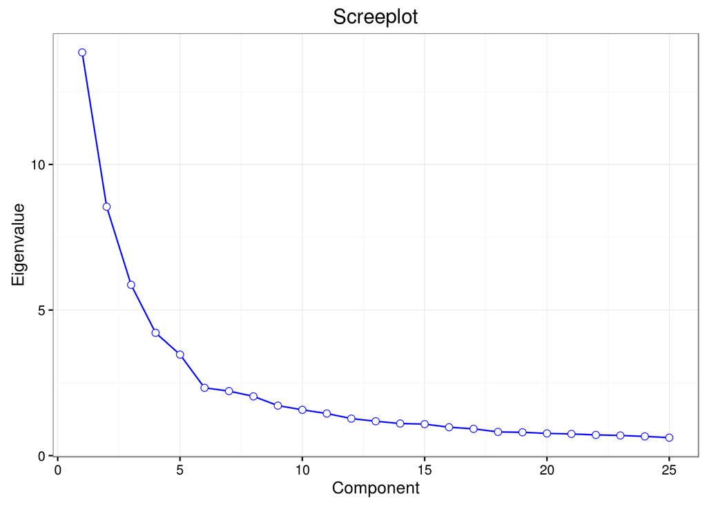

```r
# Screeplot:
screePlot <- data.frame(Component = rownames(pcaSolution$eig),
                        Eigenvalue = pcaSolution$eig$eigenvalue,
                        stringsAsFactors = F)
ggplot(screePlot,
       aes(x = seq(1,length(pcaSolution$eig$eigenvalue),1),
           y = Eigenvalue),
       label = Component) +
  geom_path(color="blue") +
  geom_point(color="blue",size = 2) +
  geom_point(color="white", size = 1.5) +
  xlab("Component") +
  ggtitle("Screeplot") +
  theme_bw()
```

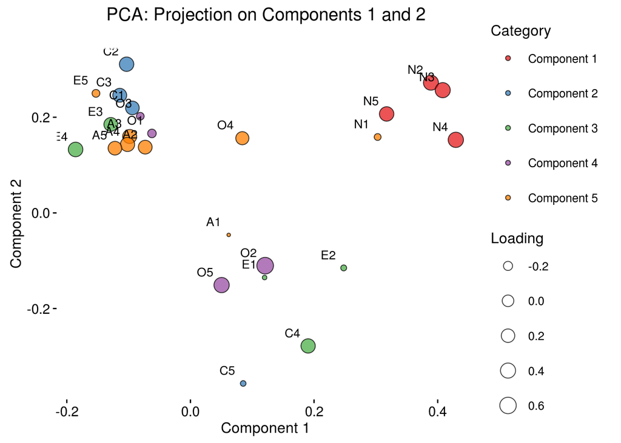

```r
# Plot loadings on PC1 and PC2
# get item coordinates
coordinates <- pcaSolution$var$coord
# compute loadings (dividing coordinates by sqrt(coord_eigenvalue))
for (i in 1:5) {
  coordinates[,i] <- coordinates[,i]/sqrt(eigenvalues[i])
}
colnames(coordinates) <- paste("Component",seq(1,dim(coordinates)[2],1),sep="")
category <- paste("Component ",unname(apply(coordinates,1,function(x){which(abs(x)==max(abs(x)))})),sep="")
loading <- unname(apply(coordinates,1,function(x){x[which(abs(x)==max(abs(x)))]}))
# prepare data.frame for {ggplot2}
plotTable <- as.data.frame(coordinates)
plotTable$Category <- category
plotTable$Loading <- loading
plotTable$Label <- rownames(plotTable)
# plot factor loadings w. {ggplot2}:
# PCA Projection on Components 1 and 2
ggplot(plotTable,aes(x = Component1,
                     y = Component2,
                     size = Loading,
                     fill = Category,
                     label = Label)) +
  geom_point(color="black",shape=21,alpha=0.75) +
  geom_text(hjust = 1.5, vjust = -1, size = 3.5) +
  theme_bw() +
  scale_size(range = c(1,6)) +
  scale_fill_brewer(palette = "Set1") +
  theme(legend.position="right") +
  theme(legend.key = element_rect(colour = NA)) +
  theme(legend.key.size=unit(1,"cm")) +
  theme(legend.background = element_rect(colour = "white", fill="white")) +
  theme(panel.border = element_rect(linetype = "solid", colour = "white", fill="NA")) +
  theme(panel.background = element_rect(fill = "white")) +
  theme(plot.background = element_blank()) +
  theme(axis.text.x = element_text(size=11,colour = "black")) +
  theme(axis.text.y = element_text(size=11,colour = "black")) +
  theme(panel.grid.minor = element_blank()) +
  theme(panel.grid.major = element_blank()) +
  xlab("Component 1") + ylab("Component 2") +
  ggtitle("PCA: Projection on Components 1 and 2\n")
```

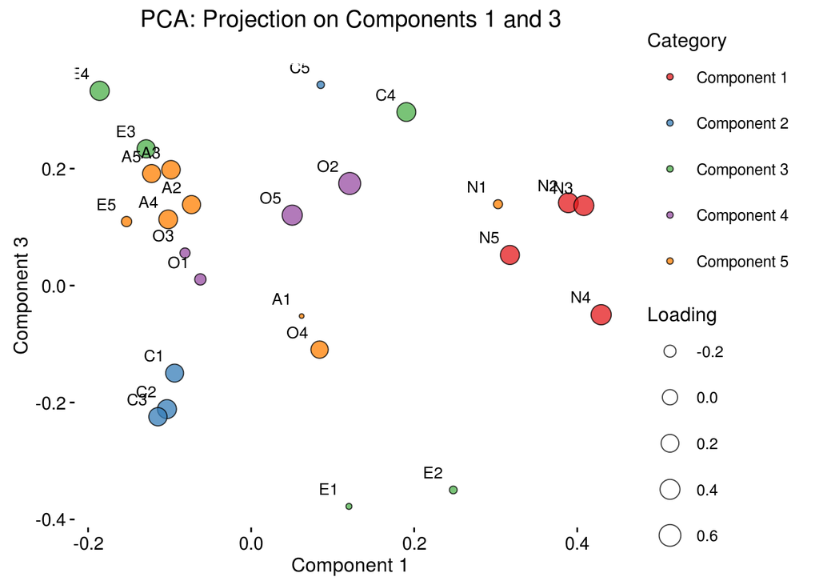

```r
# plot loadings w. {ggplot2}:
# PCA Projection on Components 1 and 3
ggplot(plotTable,aes(x = Component1,
                     y = Component3,
                     size = Loading,
                     fill = Category,
                     label = Label)) +
  geom_point(color="black",shape=21,alpha=0.75) +
  geom_text(hjust = 1.5, vjust = -1, size = 3.5) +
  theme_bw() +
  scale_size(range = c(1,6)) +
  scale_fill_brewer(palette = "Set1") +
  theme(legend.position="right") +
  theme(legend.key = element_rect(colour = NA)) +
  theme(legend.key.size=unit(1,"cm")) +
  theme(legend.background = element_rect(colour = "white", fill="white")) +
  theme(panel.border = element_rect(linetype = "solid", colour = "white", fill="NA")) +
  theme(panel.background = element_rect(fill = "white")) +
  theme(plot.background = element_blank()) +
  theme(axis.text.x = element_text(size=11,colour = "black")) +
  theme(axis.text.y = element_text(size=11,colour = "black")) +
  theme(panel.grid.minor = element_blank()) +
  theme(panel.grid.major = element_blank()) +
  xlab("Component 1") + ylab("Component 3") +
  ggtitle("PCA: Projection on Components 1 and 3\n")
```

## Readings for Session 2:

- Chapters 1 to 5 from [Norman Matloff’s The Art of R Programming](http://heather.cs.ucdavis.edu/~matloff/132/NSPpart.pdf)

#### [Data Science Serbia](http://www.datascience.rs) 2016.